# Analyzing Survival Patterns on the Titanic

#### Problem Statement:

The sinking of the RMS Titanic remains one of the most tragic maritime disasters in history. On April 15, 1912, the Titanic sank after hitting an iceberg during its maiden voyage from Southampton to New York City, resulting in the loss of over 1,500 lives. Despite the extensive loss of life, certain factors may have influenced a passenger's likelihood of survival.

In this project, we aim to analyze the Titanic dataset, which contains information about passengers who were aboard the Titanic during its ill-fated voyage. The dataset includes various features such as age, gender, ticket class, fare, cabin, port of embarkation, and survival status.

The primary objective of this project is to explore and analyze the data to identify patterns and factors that were associated with survival on the Titanic. We seek to answer questions such as:

Did certain demographics have a higher chance of survival than others? (e.g., gender, age, passenger class)

Were passengers traveling with family members more likely to survive?

Was there a significant difference in survival rates based on the port of embarkation?

Did passengers who paid higher fares have a better chance of survival?

By conducting descriptive statistics, data visualization, and exploratory data analysis (EDA), we aim to uncover insights into the dynamics of the Titanic disaster and shed light on the factors that played a role in determining survival outcomes. The findings of this analysis will contribute to our understanding of historical events and human behavior in times of crisis.

The success of this project will provide valuable insights into the demographics, social dynamics, and decision-making processes that shaped survival patterns on the Titanic.

```python
# import library to aid execute of Data visualization & EDA
import pandas as pd
import numpy as np
import seaborn as sns
import matplotlib.pyplot as plt
import plotly.express as px
```

```python
#importing data set from my PC directory through the use of Pandas
df = pd.read_csv("C:/Users/User/Downloads/Titanic-Dataset.csv")
df.head()
```

|  | PassengerId | Survived | Pclass | Name | Sex | Age | SibSp | Parch | Ticket | Fare | Cabin | Embarked |
| --- | --- | --- | --- | --- | --- | --- | --- | --- | --- | --- | --- | --- |
| 0 | 1 | 0 | 3 | Braund, Mr. Owen Harris | male | 22.0 | 1 | 0 | A/5 21171 | 7.2500 | NaN | S |
| 1 | 2 | 1 | 1 | Cumings, Mrs. John Bradley (Florence Briggs Th... | female | 38.0 | 1 | 0 | PC 17599 | 71.2833 | C85 | C |
| 2 | 3 | 1 | 3 | Heikkinen, Miss. Laina | female | 26.0 | 0 | 0 | STON/O2. 3101282 | 7.9250 | NaN | S |
| 3 | 4 | 1 | 1 | Futrelle, Mrs. Jacques Heath (Lily May Peel) | female | 35.0 | 1 | 0 | 113803 | 53.1000 | C123 | S |
| 4 | 5 | 0 | 3 | Allen, Mr. William Henry | male | 35.0 | 0 | 0 | 373450 | 8.0500 | NaN | S |

```python
#Checking the data infomation for data types, number of columns, data range
df.info()
```

```
<class 'pandas.core.frame.DataFrame'>
RangeIndex: 891 entries, 0 to 890
Data columns (total 12 columns):
 #   Column       Non-Null Count  Dtype
---  ------       --------------  -----
 0   PassengerId  891 non-null    int64
 1   Survived     891 non-null    int64
 2   Pclass       891 non-null    int64
 3   Name         891 non-null    object
 4   Sex          891 non-null    object
 5   Age          714 non-null    float64
 6   SibSp        891 non-null    int64
 7   Parch        891 non-null    int64
 8   Ticket       891 non-null    object
 9   Fare         891 non-null    float64
 10  Cabin        204 non-null    object
 11  Embarked     889 non-null    object
dtypes: float64(2), int64(5), object(5)
memory usage: 83.7+ KB
```

```python
#Checking the amount of NAN value in the data set
df.isna().sum()
```

```
PassengerId      0
Survived         0
Pclass           0
Name             0
Sex              0
Age            177
SibSp            0
Parch            0
Ticket           0
Fare             0
Cabin          687
Embarked         2
dtype: int64
```

```python
#Deriving the median for Age
median_age= df['Age'].median()
median_age
```

```
28.0
```

```python
#Replacing the NAN value in the age column with median
df['Age'].fillna(median_age, inplace = True)
```

```python
#Deriving the mode for Cabin
mode_cabin = df['Cabin'].mode()
mode_cabin
```

```
0        B96 B98
1    C23 C25 C27
2             G6
Name: Cabin, dtype: object
```

```python
#Replacing the NAN value in Cabin column with mode
df['Cabin'].fillna(mode_cabin[1], inplace = True)
```

```python
#Deriving the mode for Embarked
mode_embarked = df['Embarked'].mode()
mode_embarked
```

```
0    S
Name: Embarked, dtype: object
```

```python
#Replacing NAN value in Embarked  column with mode
df['Embarked'].fillna(mode_embarked[0], inplace = True)
```

```python
df.isna().sum()
```

```
PassengerId    0
Survived       0
Pclass         0
Name           0
Sex            0
Age            0
SibSp          0
Parch          0
Ticket         0
Fare           0
Cabin          0
Embarked       0
dtype: int64
```

```python
#Checking for outliers
df.describe()
```

|  | PassengerId | Survived | Pclass | Age | SibSp | Parch | Fare |
| --- | --- | --- | --- | --- | --- | --- | --- |
| count | 891.000000 | 891.000000 | 891.000000 | 891.000000 | 891.000000 | 891.000000 | 891.000000 |
| mean | 446.000000 | 0.383838 | 2.308642 | 29.361582 | 0.523008 | 0.381594 | 32.204208 |
| std | 257.353842 | 0.486592 | 0.836071 | 13.019697 | 1.102743 | 0.806057 | 49.693429 |
| min | 1.000000 | 0.000000 | 1.000000 | 0.420000 | 0.000000 | 0.000000 | 0.000000 |
| 25% | 223.500000 | 0.000000 | 2.000000 | 22.000000 | 0.000000 | 0.000000 | 7.910400 |
| 50% | 446.000000 | 0.000000 | 3.000000 | 28.000000 | 0.000000 | 0.000000 | 14.454200 |
| 75% | 668.500000 | 1.000000 | 3.000000 | 35.000000 | 1.000000 | 0.000000 | 31.000000 |
| max | 891.000000 | 1.000000 | 3.000000 | 80.000000 | 8.000000 | 6.000000 | 512.329200 |

#### Using Interquartile Range methods to filter the outliers for Age, SibSp, Parch and Fare

```python
Q1 = df['Age'].quantile(0.25)
Q3 = df['Age'].quantile(0.75)
thresh_value = 1.5
interquartile = Q3 - Q1

# Define the upper and lower bounds for outliers
upper_outliers = df[(df['Age'] > Q3 + thresh_value * interquartile)]
lower_outliers = df[(df['Age'] < Q1 - thresh_value * interquartile)]

# Remove both upper and lower outliers
df = df.drop(upper_outliers.index)
df = df.drop(lower_outliers.index)

# Shape of the cleaned DataFrame
df.shape
```

```
(825, 12)
```

```python
Q1 = df['Fare'].quantile(0.25)
Q3 = df['Fare'].quantile(0.75)
thresh_value = 1.5
interquartile = Q3 - Q1

# Define the upper and lower bounds for outliers
upper_outliers = df[(df['Fare'] > Q3 + thresh_value * interquartile)]
lower_outliers = df[(df['Fare'] < Q1 - thresh_value * interquartile)]

# Remove both upper and lower outliers
df = df.drop(upper_outliers.index)
df = df.drop(lower_outliers.index)

# Shape of the cleaned DataFrame
df.shape
```

```
(718, 12)
```

```python
#Cheking the result of the filtered outliers
df.describe()
```

[output not shown]

#### Objective 1: Did certain demographics have a higher chance of survival than others? (e.g., gender, age, passenger class)

##### Rate of survival in regard to Gender

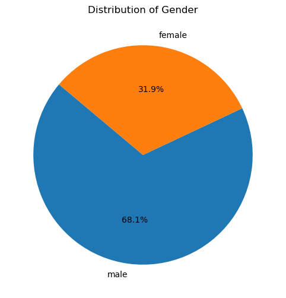

```python
# Assuming 'df' is your DataFrame containing the data
plt.figure(figsize=(12, 6))

# Count the occurrences of each category in 'Sex'
sex_counts= df['Sex'].value_counts()

# Plot a pie chart
plt.pie(sex_counts, labels=sex_counts.index, autopct='%1.1f%%', startangle=140)

# Add title
plt.title('Distribution of Gender')

# Show the plot
plt.show()
```

```python
gender_survive =df.groupby('Sex')['Survived'].value_counts()
gender_survive
```

```
Sex     Survived
female  1           157
        0            72
male    0           406
        1            83
Name: count, dtype: int64
```

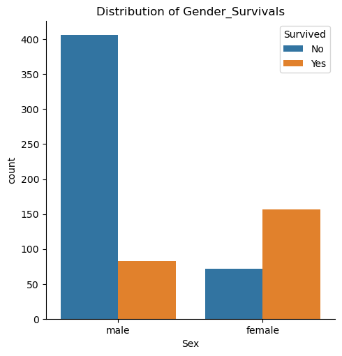

```python
#Deriving the rate of survival in regards to gender
sns.catplot(x="Sex", hue="Survived", kind="count", data=df, legend=False)
#Add legend
plt.legend(title="Survived", labels=["No", "Yes"])
# Add title
plt.title('Distribution of Gender_Survivals')
plt.show()
```

While the Titanic had a significantly higher percentage of male passengers (68.1%) compared to female passengers (31.9%), the distribution of survivors tells a different story. Despite fewer women onboard, a greater number of females survived the disaster compared to males.

The count plot analysis revealed 157 female survivors compared to around 83 male survivors. Conversely, there were 72 female non-survivors compared to roughly 406 male non-survivors. This discrepancy challenges the expectation that more men would survive based solely on their larger presence onboard.

This observation suggests that priority and preference may have been given to females during the evacuation process. Historical maritime norms, which favored the evacuation of women and children first, likely played a role in these outcomes.

#### Rate of Survivours by Class

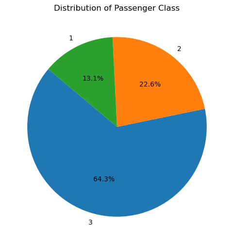

```python
plt.figure(figsize=(12, 6))

# Count the occurrences of each category in 'Pclass'
pclass_counts= df['Pclass'].value_counts()

# Plot a pie chart
plt.pie(pclass_counts, labels=pclass_counts.index, autopct='%1.1f%%', startangle=140)

# Add title
plt.title('Distribution of Passenger Class')

# Show the plot
plt.show()
```

```python
# Grouping the passengers into class and counting the survivors and non survivors in each class
class_survivors =df.groupby('Pclass')['Survived'].value_counts()
class_survivors
```

```
Pclass  Survived
1       1            53
        0            41
2       0            86
        1            76
3       0           351
        1           111
Name: count, dtype: int64
```

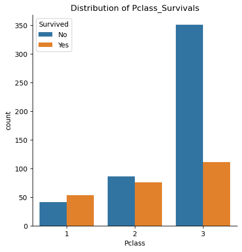

```python
sns.catplot(x="Pclass", hue="Survived", kind = "count", data=df, legend = False)
#Add legend
plt.legend(title="Survived", labels=["No", "Yes"])
# Add title
plt.title('Distribution of Pclass_Survivals')
plt.show()
```

It's evident from the distribution of passenger classes that the majority, 64.3%, belonged to third class, while 22.6% were in second class, and 13.1% were in first class.

Regarding the correlation between passenger class and survival rate, it's important to note that while there appears to be a close correlation, it's not definitive. The higher survival rate among first-class passengers compared to other-class passengers could be influenced by various factors, such as their proximity to lifeboats, potential preferential treatment due to social status, or even the ability to secure a place on a lifeboat through financial means.

However, it's essential to remember that correlation doesn't necessarily imply causation. Other variables, like age, gender, and individual actions during the disaster, may also have played a significant role in determining survival rates.

#### Rate of suvivours by Age

```python
#Converting the age column(int) to age group(string)
# Specify the age bins and labels for each age group
age_bins = [0, 18, 30, 50, 100] # 0-17(Child), 18-29(Young Adult), 30-49(Adult), 50-99(Elderly)
age_labels = ['Child', 'Young Adult', 'Adult', 'Elderly']

# Create a new column in the DataFrame to store the age group
df['Age'] = pd.cut(df['Age'], bins=age_bins, labels=age_labels, right=True)

'''
This code won't affect the original table which is above.
This is done for the purpose of vizualization
'''
```

```python
#The result of the above code
df.head()
```

[output not shown]

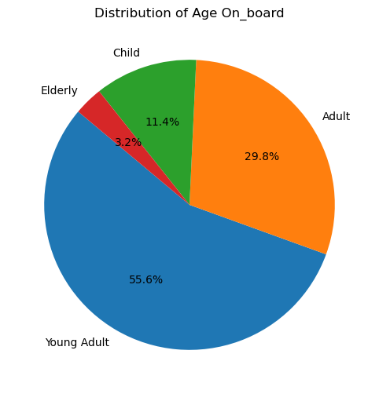

```python
plt.figure(figsize=(12, 6))

# Count the occurrences of each category in 'Pclass'
age_counts= df['Age'].value_counts()

# Plot a pie chart
plt.pie(age_counts, labels=age_counts.index, autopct='%1.1f%%', startangle=140)

# Add title
plt.title('Distribution of Age On_board')

# Show the plot
plt.show()
```

```python
df.groupby('Age')['Survived'].value_counts()
```

```
Age          Survived
Child        0            43
             1            39
Young Adult  0           278
             1           121
Adult        0           142
             1            72
Elderly      0            15
             1             8
Name: count, dtype: int64
```

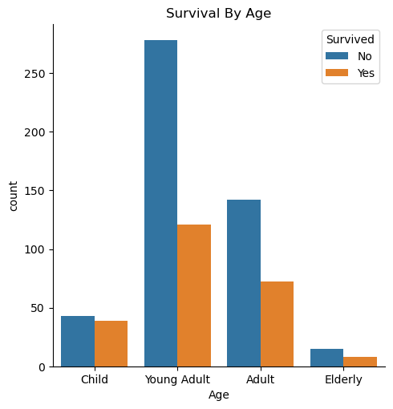

```python
sns.catplot(x="Age", hue="Survived", kind="count", data=df, legend=False)
plt.legend(title="Survived", labels=["No", "Yes"])
plt.title('Survival By Age')
plt.show()
```

This trend may be attributed to maritime safety protocols that prioritize children, women, and the elderly during emergencies

#### Objective 2: Were passengers traveling with family members more likely to survive?

In this section they are two categories of family memebers which are: those traveling with Parent or child(ren) a.k.a Parch and those traveling with Siblings or Spouse a.k.a SIbSp

We will be analyzing them together by merging the two column for better analysis or visualization

```python
df = pd.DataFrame(df)

# Merge two integer columns together
df['Family'] = df['Parch'] + df['SibSp']
```

```python
#Checking the code
df.head()
```

|  | PassengerId | Survived | Pclass | Name | Sex | Age | SibSp | Parch | Ticket | Fare | Cabin | Embarked | Family |
| --- | --- | --- | --- | --- | --- | --- | --- | --- | --- | --- | --- | --- | --- |
| 0 | 1 | 0 | 3 | Braund, Mr. Owen Harris | male | Young Adult | 1 | 0 | A/5 21171 | 7.2500 | C23 C25 C27 | S | 1 |
| 2 | 3 | 1 | 3 | Heikkinen, Miss. Laina | female | Young Adult | 0 | 0 | STON/O2. 3101282 | 7.9250 | C23 C25 C27 | S | 0 |
| 3 | 4 | 1 | 1 | Futrelle, Mrs. Jacques Heath (Lily May Peel) | female | Adult | 1 | 0 | 113803 | 53.1000 | C123 | S | 1 |
| 4 | 5 | 0 | 3 | Allen, Mr. William Henry | male | Adult | 0 | 0 | 373450 | 8.0500 | C23 C25 C27 | S | 0 |
| 5 | 6 | 0 | 3 | Moran, Mr. James | male | Young Adult | 0 | 0 | 330877 | 8.4583 | C23 C25 C27 | Q | 0 |

```python
parch_survive = df.groupby('Survived')[['Family']].value_counts()
parch_survive
```

```
Survived  Family
0         0         343
          1          60
          2          33
          5          13
          4          11
          6           7
          3           6
          7           5
1         0         130
          1          56
          2          38
          3          10
          6           4
          4           1
          5           1
Name: count, dtype: int64
```

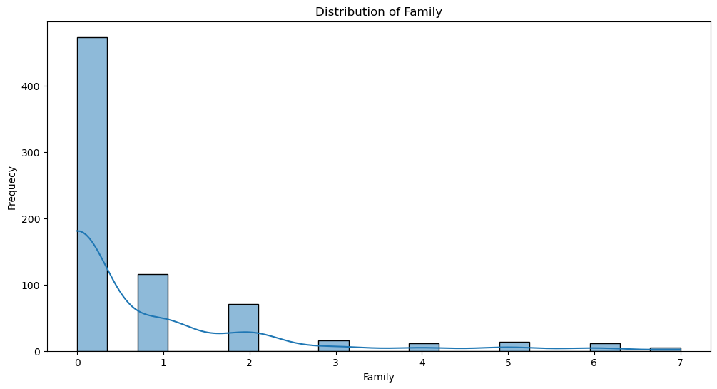

```python
plt.figure(figsize=(12, 6))
sns.histplot(df['Family'], bins=20, kde=True)
plt.title('Distribution of Family')
plt.xlabel('Family')
plt.ylabel('Frequecy')
plt.show()
```

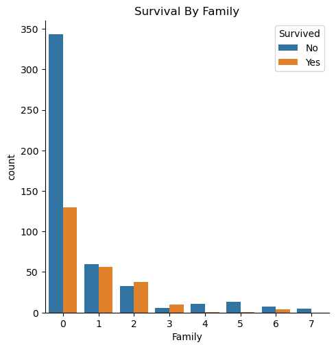

```python
sns.catplot(x="Family", hue="Survived", kind="count", data=df, legend=False)
plt.legend(title="Survived", labels=["No", "Yes"])
plt.title('Survival By Family')
plt.show()
```

#### Objective 3: Was there a significant difference in survival rates based on the port of embarkation?

```python
df.groupby('Embarked')['Survived'].value_counts()
```

```
Embarked  Survived
C         0            59
          1            45
Q         0            42
          1            29
S         0           377
          1           166
Name: count, dtype: int64
```

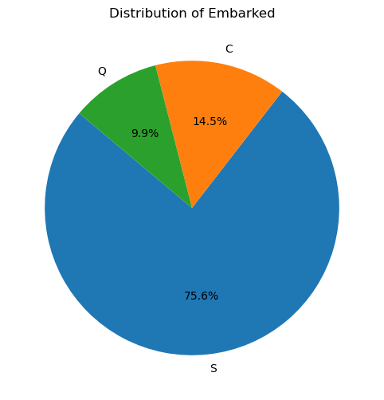

```python
# Assuming 'df' is your DataFrame containing the data
plt.figure(figsize=(12, 6))

# Count the occurrences of each category in 'Embarked'
embarked_counts= df['Embarked'].value_counts()

# Plot a pie chart
plt.pie(embarked_counts, labels=embarked_counts.index, autopct='%1.1f%%', startangle=140)

# Add title
plt.title('Distribution of Embarked')

# Show the plot
plt.show()
```

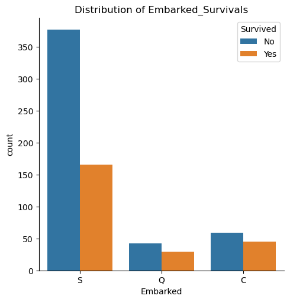

```python
sns.catplot(x="Embarked", hue="Survived", kind="count", data=df, legend=False)
#Add legend
plt.legend(title="Survived", labels=["No", "Yes"])
# Add title
plt.title('Distribution of Embarked_Survivals')
plt.show()
```

Port of Embarkation:C = Cherbourg, Q = Queenstown, S = Southampton

#### Objective 4: Did passengers who paid higher fares have a better chance of survival?

```python
#Converting the Fare column(int) to age group(string)
# Specify the fare bins and labels for each age group
fare_bins = [0, 15, 30, 45, 65]
fare_labels = ['$0-14', '$15-29', '$30-44', '$45-65']

# Create a new column in the DataFrame to store the fare group
df['Group_Fare'] = pd.cut(df['Fare'], bins=fare_bins, labels=fare_labels, right=True)

'''
This code won't affect the original table which is above.
This is done for the purpose of vizualization
'''
```

```python
df.head()
```

|  | PassengerId | Survived | Pclass | Name | Sex | Age | SibSp | Parch | Ticket | Fare | Cabin | Embarked | Family | Group_Fare |
| --- | --- | --- | --- | --- | --- | --- | --- | --- | --- | --- | --- | --- | --- | --- |
| 0 | 1 | 0 | 3 | Braund, Mr. Owen Harris | male | Young Adult | 1 | 0 | A/5 21171 | 7.2500 | C23 C25 C27 | S | 1 | $0-14 |
| 2 | 3 | 1 | 3 | Heikkinen, Miss. Laina | female | Young Adult | 0 | 0 | STON/O2. 3101282 | 7.9250 | C23 C25 C27 | S | 0 | $0-14 |
| 3 | 4 | 1 | 1 | Futrelle, Mrs. Jacques Heath (Lily May Peel) | female | Adult | 1 | 0 | 113803 | 53.1000 | C123 | S | 1 | $45-65 |
| 4 | 5 | 0 | 3 | Allen, Mr. William Henry | male | Adult | 0 | 0 | 373450 | 8.0500 | C23 C25 C27 | S | 0 | $0-14 |
| 5 | 6 | 0 | 3 | Moran, Mr. James | male | Young Adult | 0 | 0 | 330877 | 8.4583 | C23 C25 C27 | Q | 0 | $0-14 |

```python
survived_by_fare = df.groupby('Group_Fare')['Survived'].value_counts()
survived_by_fare
```

```
Group_Fare  Survived
$0-14       0           318
            1           107
$15-29      0            97
            1            81
$30-44      0            29
            1            22
$45-65      1            29
            0            20
Name: count, dtype: int64
```

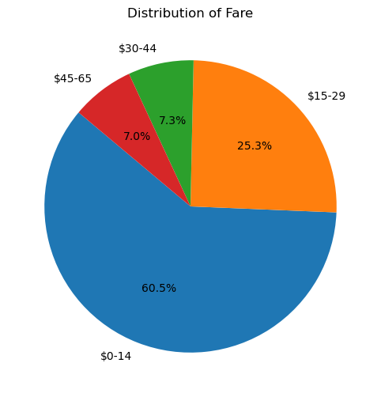

```python
# Assuming 'df' is your DataFrame containing the data
plt.figure(figsize=(12, 6))

# Count the occurrences of each category in 'Fare'
fare_counts= df['Group_Fare'].value_counts()

# Plot a pie chart
plt.pie(fare_counts, labels=fare_counts.index, autopct='%1.1f%%', startangle=140)

# Add title
plt.title('Distribution of Fare')

# Show the plot
plt.show()
```

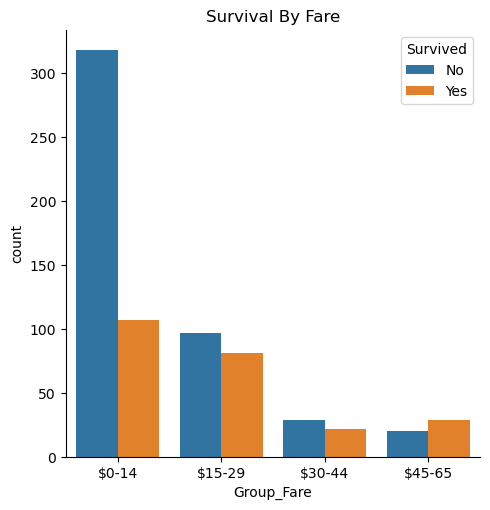

```python
sns.catplot(x="Group_Fare", hue="Survived", kind="count", data=df, legend=False)
plt.legend(title="Survived", labels=["No", "Yes"])
plt.title('Survival By Fare')
plt.show()
```

The distribution graph illustrates the population distribution across different fare groups. Notably, the 0-14 fare group comprises the largest percentage, accounting for 60.5% of the total, followed by 15-29 (25.3%), 30-45 (7.3%), and 45-65 (7.0%).

Regarding the correlation between fare and passenger survival, it's important to note that while there might be a correlation, it's not conclusive evidence. The $45-65 fare group does exhibit a higher survival rate, suggesting a potential correlation. However, this alone is not sufficient to form a definitive argument.

It's crucial to remember that correlation doesn't imply causation. Other variables, such as age, gender, and individual actions during the disaster, likely played significant roles in determining survival rates.

Further analysis, considering additional variables, is necessary to gain a more comprehensive understanding of the factors influencing survival rates among Titanic passengers.

```python
corr_titanic = df[['Pclass', 'Family', 'Survived', 'Fare']].corr()
corr_titanic
```

|  | Pclass | Family | Survived | Fare |
| --- | --- | --- | --- | --- |
| Pclass | 1.000000 | 0.092417 | -0.268318 | -0.594245 |
| Family | 0.092417 | 1.000000 | 0.042121 | 0.419145 |
| Survived | -0.268318 | 0.042121 | 1.000000 | 0.247519 |
| Fare | -0.594245 | 0.419145 | 0.247519 | 1.000000 |

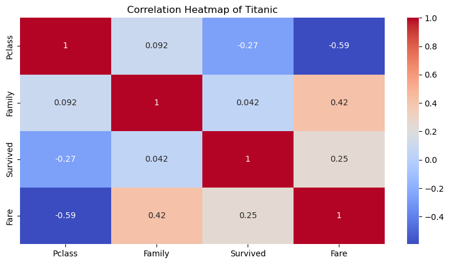

```python
plt.figure(figsize=(10, 5))
sns.heatmap(corr_titanic,
            annot=True,
            cmap='coolwarm')
plt.title("Correlation Heatmap of Titanic")
plt.show()
```

The heat map represents the correlation between numerical columns in the dataset. A correlation coefficient of 1 indicates a perfect positive correlation, while a coefficient less than 1 suggests a close correlation. Negative correlation coefficients indicate a negative correlation between the variables.

It's important to note that correlation coefficients close to 1 or -1 signify stronger relationships between variables, whereas coefficients closer to 0 indicate weaker correlations.

Using this heat map, we can visually identify the strength and direction of relationships between different numerical features in the dataset.